# COMPSCIX 415.2 Homework 6

Elizabeth Eldridge

March 5, 2019

## Exercise 1

Load the Whickham dataset (data(Whickham)). You will need to load the mosaicData package first, but I also included the data as a csv file on Canvas if you would rather download it there and load it with the readr package.

Look at the help file on this dataset to learn a bit about it. Note that the help file only exists if you are using the dataset from the mosaicData package. If you are loading the dataset from the csv file, do a Google search of this dataset and package name to help answer the first two questions below.

```r
library(mosaicData)
(data(Whickham))
```

```
## [1] "Whickham"
```

```r
?Whickham
```

```
## starting httpd help server ... done
```

```r
names(Whickham)
```

```
## [1] "outcome" "smoker"  "age"
```

```r
head(Whickham, 20)
```

```
##    outcome smoker age
## 1    Alive    Yes  23
## 2    Alive    Yes  18
## 3     Dead    Yes  71
## 4    Alive     No  67
## 5    Alive     No  64
## 6    Alive    Yes  38
## 7    Alive    Yes  45
## 8     Dead     No  76
## 9    Alive     No  28
## 10   Alive     No  27
## 11   Alive     No  28
## 12   Alive    Yes  34
## 13   Alive     No  20
## 14    Dead    Yes  72
## 15   Alive    Yes  48
## 16   Alive    Yes  45
## 17    Dead     No  66
## 18   Alive    Yes  30
## 19   Alive     No  67
## 20   Alive    Yes  33
```

1. What variables are in this data set?
- The variables in the dataset are: outcome, smoker, and age.
2. How many observations are there and what does each represent?
- There are 1314 observations in this data and each represents a woman on the electoral roll in Whickham.
3. Create a table (use the R code below as a guide) and a visualization of the relationship between smoking status and outcome, ignoring age. What do you see? Does it make sense?
- I’m seeing that using this method, the two variables in this plot will need to be recoded as numeric variables rather than character variables in order to plot in a useful way.

```r
Whickham %>% count( smoker , outcome )
```

```
## # A tibble: 4 x 3
##   smoker outcome     n
##   <fct>  <fct>   <int>
## 1 No     Alive     502
## 2 No     Dead      230
## 3 Yes    Alive     443
## 4 Yes    Dead      139
```

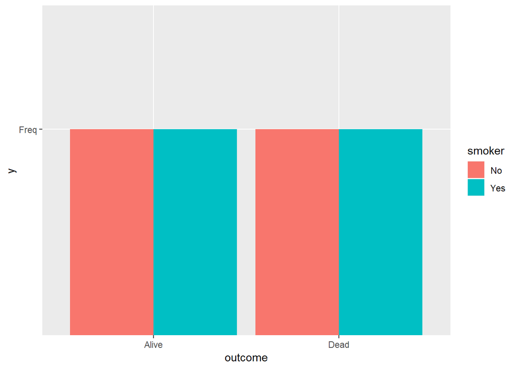

```r
ggplot(data = Whickham) +
    geom_bar(aes(x = outcome, y = "Freq", fill = smoker), stat = 'identity', position = position_dodge())
```

```r
#View(Whickham)
#Whickham$num_outcome <- as.numeric(Whickham$smoker)

head(Whickham$num_outcome)
```

```r
###
Whickham %>% mutate(Count_outc = as.numeric(outcome))
```

[output not shown]

[output cut: 1300 more lines]

```r
head(Whickham)
```

```
##   outcome smoker age
## 1   Alive    Yes  23
## 2   Alive    Yes  18
## 3    Dead    Yes  71
## 4   Alive     No  67
## 5   Alive     No  64
## 6   Alive    Yes  38
```

```r
Whickham <- Whickham %>% mutate(new_Outc = factor(outcome, levels = c(0,1))) %>%
    mutate(new_Outc2 = as.numeric(new_Outc))

#Whickham2 <- Whickham %>% recode(outcome,
#                      c('Alive' = '0', 'Dead' = '1'))

Whickham <- Whickham %>%
    mutate(age_cat = case_when(age <= 44 ~ '44 or less',
                     (age > 44 & age <= 64) ~ '44 to less than 65',
                      age > 64 ~ 'over 64'))

Whickham$age_factor <- factor(Whickham$age_cat)

class(Whickham$age_factor)
```

```
## [1] "factor"
```

```r
head(Whickham$age_factor)
```

```
## [1] 44 or less         44 or less         over 64
## [4] over 64            44 to less than 65 44 or less
## Levels: 44 or less 44 to less than 65 over 64
```

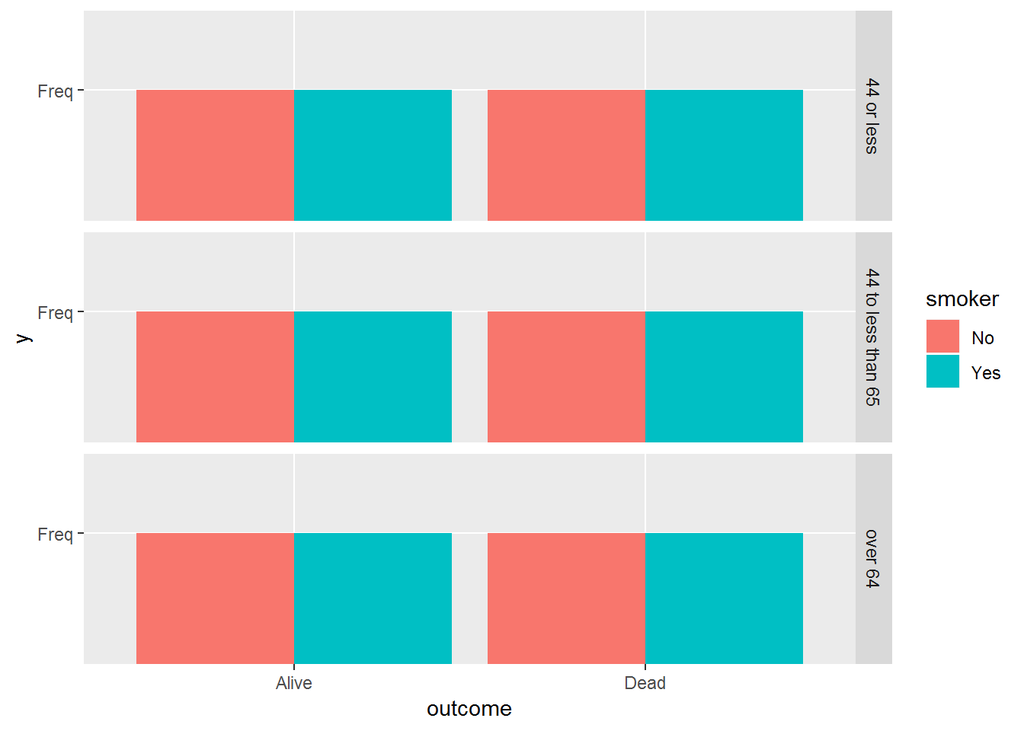

```r
#facet
ggplot(data = Whickham) +
    geom_bar(aes(x = outcome, y = "Freq", fill = smoker), stat = 'identity', position = position_dodge()) +
    facet_grid(vars(age_cat))
```

4. Recode the age variable into an ordered factor with three categories: age <= 44, age > 44 & age <= 64, and age > 64. Now, recreate visualization from above, but facet on your new age factor. What do you see? Does it make sense?
- When the outcome variable is recoded as a numeric variable, I would expect to see that we start to see a greater outcome of ‘Death’ among the older age group, regardless of smoker status.

## Exercise 2

The Central Limit Theorem states that the sampling distribution of sample means is approximately Normal, regardless of the distribution of your population. For this exercise our population distribution will be a Gamma(1,2) distribution, and we’ll show that the sampling distribution of the mean is in fact normally distributed.

1. Generate a random sample of size n = 10000 from a gamma(1,2) distribution and plot a histogram or density curve. Use the code below to help you get your sample.

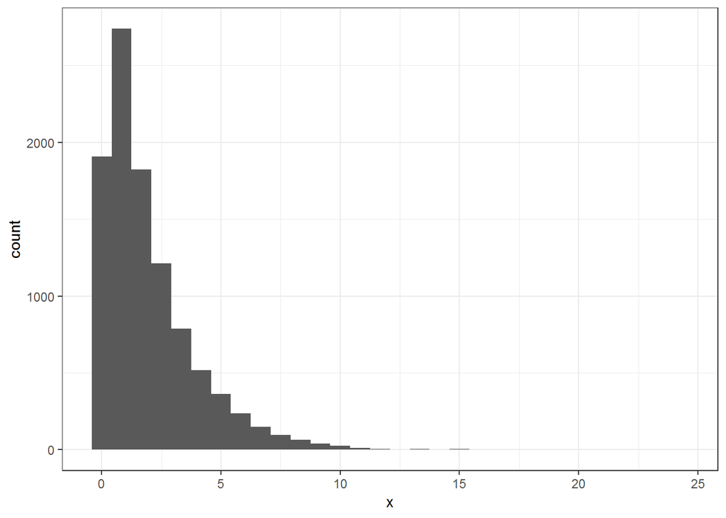

```r
library(tidyverse)
n <- 10000
# look at ?rgamma to read about this function
gamma_samp <- tibble(x = rgamma(n, shape = 1, scale = 2))

gamma_samp %>% ggplot() +
  geom_histogram(aes(x = x), bindwidth = 10) +
  theme_bw()
```

2. What is the mean and standard deviation of your sample? They should both be close to 2 because for a gamma distribution:

mean = shape x scale variance = shape x scaleˆ2

```r
mean_samp <- gamma_samp %>% .[['x']] %>% mean()
mean_samp
```

```
## [1] 1.982905
```

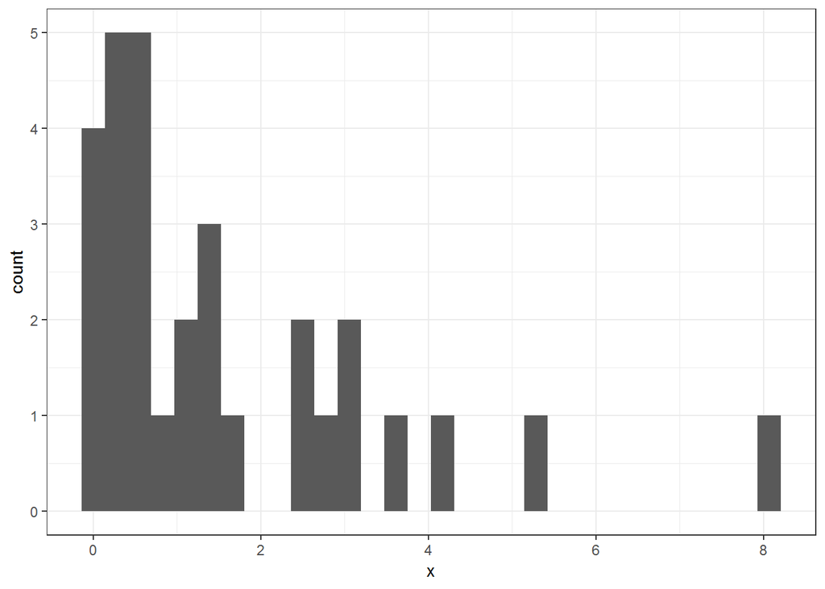

```r
gamma_samp %>% sample_n(30) %>% ggplot() +
  geom_histogram(aes(x = x), bindwidth = 10) +
  theme_bw()
```

```r
samp1 <- gamma_samp %>% sample_n(30)

mean_samp1 <- samp1 %>% .[['x']] %>% mean()
mean_samp1 #2.022
```

```
## [1] 1.850215
```

```r
sd_samp <- gamma_samp %>% .[['x']] %>% sd()
sd_samp   #1.98
```

```
## [1] 1.961221
```

4. Take a sample of size n = 30, again from the Gamma(1,2) distribution, calculate the mean, and assign it to a vector named mean_samp. Repeat this 10000 times!!!! The code below might help.

```r
# create a vector with 10000 NAs
mean_samp <- rep(NA, 10000)
# start a loop
for(i in 1:10000) {
g_samp <- rgamma(30, shape = 1, scale = 2)
mean_samp[i] <- mean(g_samp)
}
# Convert vector to a tibble
mean_samp <- tibble(mean_samp)
mean_samp
```

```
## # A tibble: 10,000 x 1
##    mean_samp
##        <dbl>
##  1      1.41
##  2      1.97
##  3      2.51
##  4      1.75
##  5      1.32
##  6      2.35
##  7      2.09
##  8      2.02
##  9      2.03
## 10      1.57
## # ... with 9,990 more rows
```

5. Make a histogram of your collection of means from above (mean_samp).

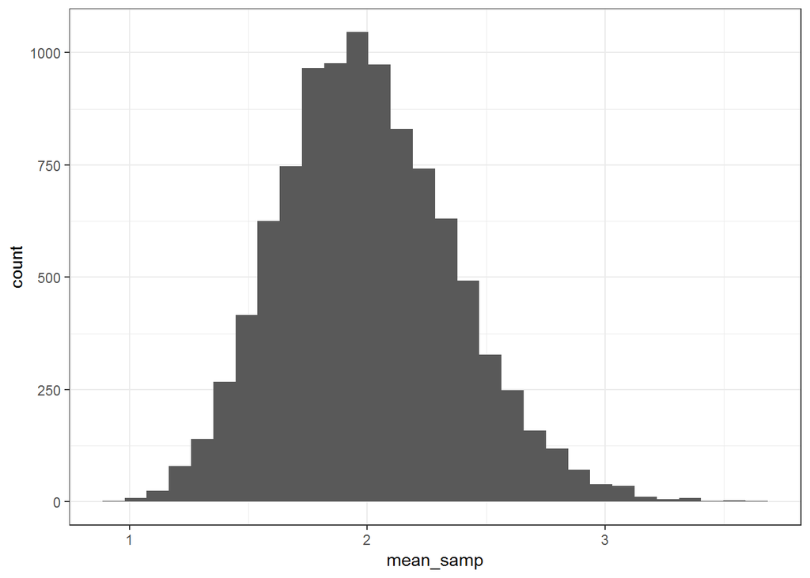

```r
mean_samp %>%  ggplot() +
  geom_histogram(aes(x = mean_samp), bindwidth = 10) +
  theme_bw()
```

```r
#mean_Samp2 <- rep(NA, 10000)
#for(i in 1:10000) {
#mean_Samp2[i] <- mean_samp %>% sample_n(300) %>%
#  summarize(meanvar = mean(mean_samp, na.rm = TRUE),
#                        sd_var = sd(mean_samp, na.rm = TRUE))
#                  }
#mean_samp2

##crashes my R session.
```